# 00.scRNA-seq: fit zero proportions

I’d create a loom object containing test scRNA-seq data and fit simple model to assess 0 inflation.

Ming  
2021-11-20

One feature of single cell RNA-seq data is the abundance of ‘0’. There are papers talking about both technical and biological sources of these ‘0’, I list some of them at the end of this post.

I’m gonna write a series of posts, talking about how to model gene expression in single cell data, such as if there is 0 inflation, how to fit statistical models, how to interpete the fitting result.

This post is the first one of the series.

In this post, I’d

- generate a test dataset in ‘loom’ format of one fly tissue from the `Fly Cell Atals` public database.
- plot mean ~ var relationship for genes
- fit gene expression using negative binomial model and show the fitting result

## Generate a loom object containing sample scRNA-seq data

```r
## use SCopeLoomR to read loom file
## save three pieces of information
## cell.info, gene.names, raw matrix data
if(F){remotes::install_github("aertslab/SCopeLoomR")}
library(SCopeLoomR)

# Fly Cell Atlas: https://flycellatlas.org/
# use wing tisse '10x, Stringent, Loom' as an example
loom_path <- 's_fca_biohub_wing_10x.loom'
loom <- open_loom(loom_path, mode="r+")

cell.info=get_cell_annotation(loom)
dim(cell.info)
#[1] 15889   347

gene.names=get_genes(loom)
length(gene.names)
#13411

raw <- get_dgem(loom)
raw[1:5,1:5]
dim(raw)
#[1] 13411 15889

close_loom(loom)

## all three pieces of information collected
## generate a sample data stored in loom format
## select two cell types and save a new loom object
pick=names(sort(table(cell.info$annotation)))[c(2,3)]
pick
#[1] "muscle cell" "hemocyte"

cell.info.sub=cell.info[cell.info$annotation %in% pick,]
raw.sub=raw[,cell.info$annotation %in% pick]
dim(cell.info.sub)
#[1] 302 347
dim(raw.sub)
#[1] 13411   302
length(gene.names)
#[1] 13411
sum(rownames(raw.sub)==gene.names)
#[1] 13411

cell.info.sub.list=list(
  cell.type=cell.info.sub$annotation,
  sex.label=cell.info.sub$sex)

#https://rdrr.io/github/mojaveazure/loomR/man/create.html
library(loomR)
create('wing_2celltypes_10x.loom',data=raw.sub,cell.attrs=cell.info.sub.list)
```

The test sample data is done. I chose to store it in **loom** format due to its small size and read it inside R whenever in use.

```r
## read in small loomR file
library(loomR)
ds <- connect('wing_2celltypes_10x.loom')
mat <- t(ds$matrix[,])
gene.names <- ds$row.attrs$Gene[]
cell.names <- ds$col.attrs$CellID[]
cell.types<-ds$col.attrs$cell.type[]
sex.labels<-ds$col.attrs$sex.label[]
ds$close_all()

dim(mat)
```

```
[1] 13411   302
```

```r
length(gene.names)
```

```
[1] 13411
```

```r
length(cell.names)
```

```
[1] 302
```

```r
table(cell.types)
```

```
cell.types
   hemocyte muscle cell
        158         144
```

```r
table(sex.labels)
```

```
sex.labels
female   male
   103    199
```

## Plot mean ~ var for genes

```r
# select one cell.type for following analysis
(cell.type=unique(cell.types)[1])
```

```
[1] "muscle cell"
```

```r
mat1=mat[,cell.types==cell.type]

# exclude genes that are zero all all cells
gg<-Matrix::rowSums(mat1)>0
Y<-mat[gg,]
dim(Y)
```

```
[1] 7419  302
```

```r
library(sparseMatrixStats)
gene_means<- sparseMatrixStats::rowMeans2(Y)
gene_vars<- sparseMatrixStats::rowVars(Y)
length(gene_means);length(gene_vars)
```

```
[1] 7419
```

```
[1] 7419
```

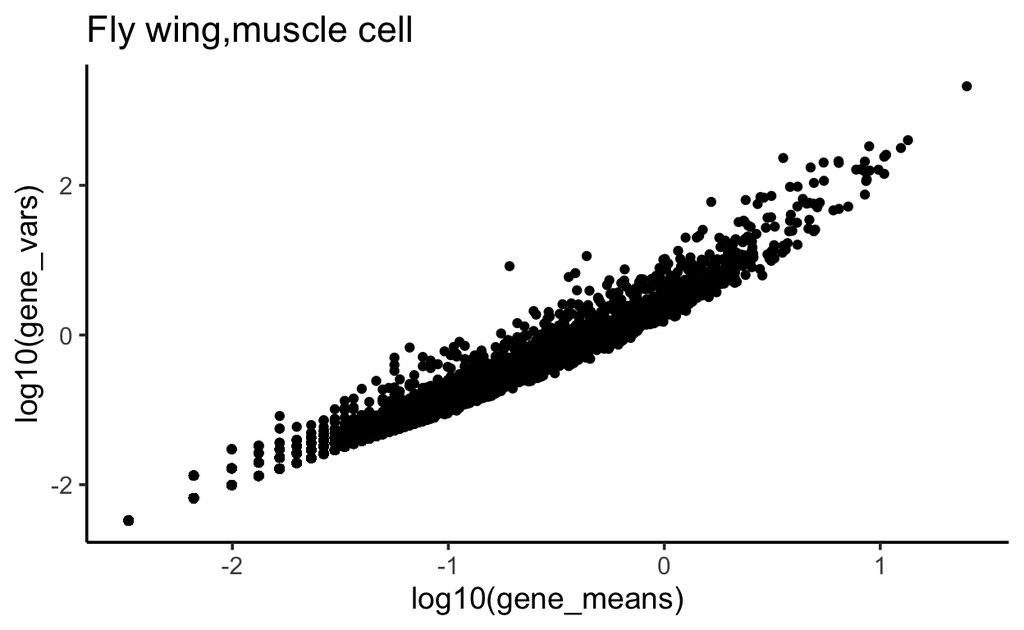

```r
library(tidyverse)
df<- bind_cols(gene_means = gene_means, gene_vars = gene_vars)
# the quadratic polynomial mean-variance relation
df %>% ggplot(aes(x = log10(gene_means), y = log10(gene_vars))) +
  geom_point() +
  theme_classic(base_size = 14) +
  ggtitle(paste0("Fly wing,",cell.type))
```

## Fit Negative.binomial distribution model by plug-in

From above, the [quadratic polynomial mean-variance relation](https://www.nxn.se/valent/2018/1/30/count-depth-variation-makes-poisson-scrna-seq-data-negative-binomial) is pretty obvious.

For [NB distribution](https://en.wikipedia.org/wiki/Negative_binomial_distribution)

one way of parameterization is:

- Mean: mu
- Var = mu + phi * mu^2

I used **gene_means** as a empirical estimation of NB parameter *mu* and to performed a linear regression to estimate *phi*.

```r
# plug in empirical mean and var to estimate phi
model<- lm(gene_vars ~  1* gene_means + I(gene_means^2) + 0, data =df )
x=summary(model)
x$coefficients
```

```
                Estimate Std. Error  t value Pr(>|t|)
I(gene_means^2) 2.994183 0.00904527 331.0219        0
```

## Is single cell RNAseq data 0 inflated?

With `mu` and `phi` estimated, plot the fitted values with the observed ones.

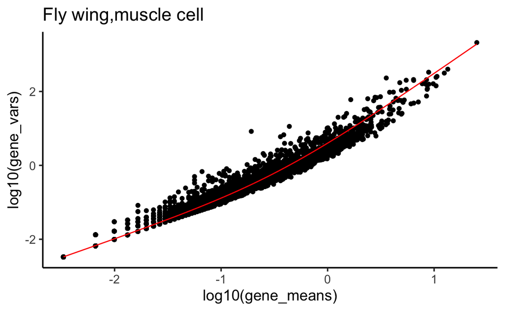

```r
#plot fitter curve with obs data
predicted_df<- data.frame(mean = df$gene_means, var_predict =
                            df$gene_means + x$coefficients[1] * (df$gene_means)^2 )

df %>%  ggplot(aes(x = log10(gene_means), y = log10(gene_vars))) +
  geom_point() +
  geom_line(color = "red", data = predicted_df, aes(x = log10(gene_means), y =log10(var_predict))) +
  theme_classic(base_size = 14) +
  ggtitle(paste0("Fly wing,",cell.type))
```

Calculate the expected `zero percentage` and compare it with the observation.

(https://divingintogeneticsandgenomics.rbind.io/post/negative-binomial-distribution-in-scrnaseq/)

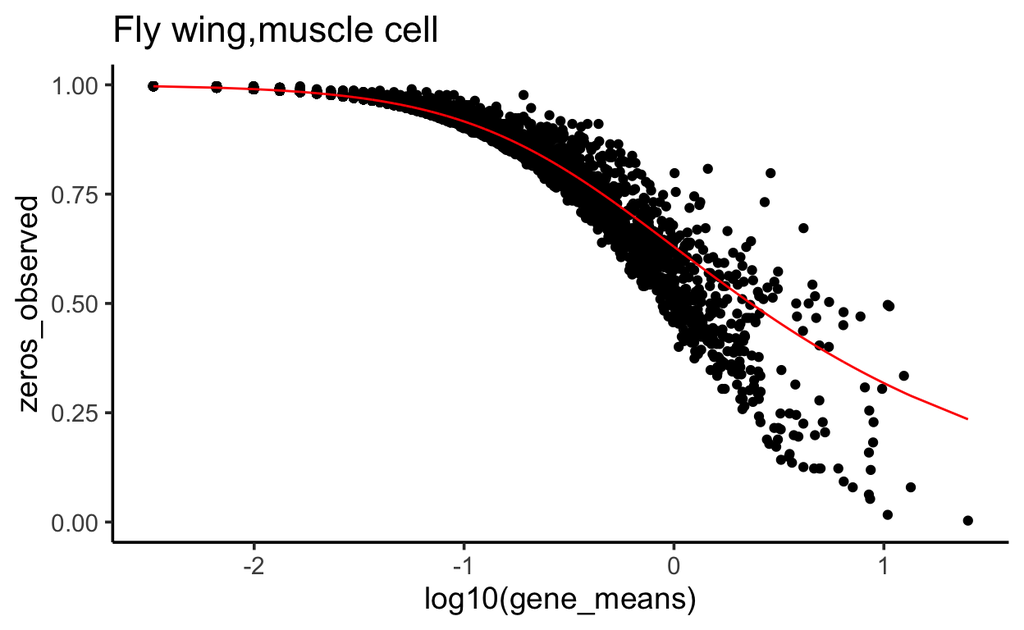

```r
phi <- 1/x$coefficients[1]
zeros_nb<- (phi/(gene_means + phi))^phi
zeros_observed<- apply(Y, 1, function(x) mean(x ==0))

data.frame(zeros_nb = zeros_nb, zeros_observed = zeros_observed,
           gene_means = gene_means) %>%
  ggplot(aes(x =log10(gene_means), y = zeros_observed)) +
  geom_point() +
  geom_line(aes(x = log10(gene_means), y = zeros_nb), color = "red") +
  theme_classic(base_size = 14) +
  ggtitle(paste0("Fly wing,",cell.type))
```

It didn’t fit that well for highly expressed genes at the right tail.

I’d use a varity of statistical models fitting gene expression for single cell data in future posts.

## References

This blog is inspired by

1. https://www.nxn.se/valent/2017/11/16/droplet-scrna-seq-is-not-zero-inflated
2. https://divingintogeneticsandgenomics.rbind.io/post/negative-binomial-distribution-in-scrnaseq/
3. https://divingintogeneticsandgenomics.rbind.io/post/negative-bionomial-distribution-in-single-cell-rnaseq/
4. https://github.com/willtownes/scrna2019/blob/master/real/svensson_2019/01_exploratory.Rmd
5. https://divingintogeneticsandgenomics.rbind.io/post/modeling-single-cell-rnaseq-data-with-multinomial-distribution/
6. https://www.nxn.se/valent/2018/1/30/count-depth-variation-makes-poisson-scrna-seq-data-negative-binomial

Further reading

- Svensson, Valentine. “Droplet scRNA-seq is not zero-inflated.” Nature Biotechnology 38.2 (2020): 147-150.
- Sarkar, Abhishek, and Matthew Stephens. “Separating measurement and expression models clarifies confusion in single-cell RNA sequencing analysis.” Nature Genetics 53.6 (2021): 770-777.
- Choi, Kwangbom, et al. “Bayesian model selection reveals biological origins of zero inflation in single-cell transcriptomics.” Genome biology 21.1 (2020): 1-16.
- Li, Wei Vivian, and Yanzeng Li. “sclink: Inferring sparse gene co-expression networks from single-cell expression data.” bioRxiv (2020).